# Investigate a Dataset - Titanic Data

1. Introduction
2. Questions to explore
3. First look at the data
   - 3.1. Missing values
4. Exploration and Visualization
   - 4.1. Did travel class play a role in survival?
   - 4.2. Were women more likely to survive than men?
   - 4.3. Did people with family aboard the ship have a better chance of survival?
   - 4.4. Did age impact survival?
   - 4.5. What is the combined role of class, sex and age on survival?
5. Conclusion
6. References

# 1. Introduction

RMS Titanic was a British passenger liner that sank in the North Atlantic Ocean in the early morning of 15 April 1912, after colliding with an iceberg during her maiden voyage from Southampton to New York City. Of the estimated 2,224 passengers and crew aboard, more than 1,500 died, making it one of the deadliest commercial peacetime maritime disasters in modern history.

One of the reasosns that led to the loss of life was the lack of enough lifeboats. Although some amount of luck was involved in surviving the disaster, in this project we analyse some of the factors that may have helped some passengers survive and others not.

# 2. Questions to explore

Here are some questions that I would like to explore from this data

1. Did travel class play a role in suvival?
2. Were women more likely to survive than men?
3. Did people with family onboard the ship have a better change of surviving?
4. Did age impact survival?
5. What is the combined role of age, gender and travel class on survival?

# 3. First look at the data

```python
# import libraries

import numpy as np
import pandas as pd
from scipy.stats import chi2_contingency
```

```python
# import libraries for plots
import matplotlib.pyplot as plt
import seaborn as sns
sns.set(style="whitegrid", color_codes=True)
```

```python
# Load the CSV

titanic_data = pd.read_csv('titanic-data.csv')

# Take a look at the first few rows

titanic_data.head()
```

|  | PassengerId | Survived | Pclass | Name | Sex | Age | SibSp | Parch | Ticket | Fare | Cabin | Embarked |
| --- | --- | --- | --- | --- | --- | --- | --- | --- | --- | --- | --- | --- |
| 0 | 1 | 0 | 3 | Braund, Mr. Owen Harris | male | 22.0 | 1 | 0 | A/5 21171 | 7.2500 | NaN | S |
| 1 | 2 | 1 | 1 | Cumings, Mrs. John Bradley (Florence Briggs Th... | female | 38.0 | 1 | 0 | PC 17599 | 71.2833 | C85 | C |
| 2 | 3 | 1 | 3 | Heikkinen, Miss. Laina | female | 26.0 | 0 | 0 | STON/O2. 3101282 | 7.9250 | NaN | S |
| 3 | 4 | 1 | 1 | Futrelle, Mrs. Jacques Heath (Lily May Peel) | female | 35.0 | 1 | 0 | 113803 | 53.1000 | C123 | S |
| 4 | 5 | 0 | 3 | Allen, Mr. William Henry | male | 35.0 | 0 | 0 | 373450 | 8.0500 | NaN | S |

The Kaggle website contains definitions for the variables in the data. The Pclass represents the ticket class and is also a proxy for socio-economic status (SES) 1st = Upper 2nd = Middle 3rd = Lower.

SibSp stands for number of siblings / spouses aboard the Titanic. Parch stands for number of parents / children aboard the Titanic.

Embarked stands for The Port of Embarkation  
C = Cherbourg, Q = Queenstown, S = Southampton

## 3.1 Missing values

```python
titanic_data.info()
```

```
<class 'pandas.core.frame.DataFrame'>
RangeIndex: 891 entries, 0 to 890
Data columns (total 12 columns):
PassengerId    891 non-null int64
Survived       891 non-null int64
Pclass         891 non-null int64
Name           891 non-null object
Sex            891 non-null object
Age            714 non-null float64
SibSp          891 non-null int64
Parch          891 non-null int64
Ticket         891 non-null object
Fare           891 non-null float64
Cabin          204 non-null object
Embarked       889 non-null object
dtypes: float64(2), int64(5), object(5)
memory usage: 83.6+ KB
```

We notice that 3 variables has missing values.

1. **Age**: It is possible to use other characteristics related to the missing field and impute the missing values. But since we have only 891 observations, testing the imputations is hard. Hence we will go ahead and omit the null values for age.
2. **Cabin and Embarked**: Since we are not going to answer any questions on these variables, we can ignore them for our analysis.

```python
# Remove the rows with missing age value
titanic_no_missing = titanic_data[pd.notnull(titanic_data['Age'])]

# Replace values 0 and 1 in Survived column with meaningful text
titanic_no_missing['Survived'].replace({0:'Died',1:'Survived'},inplace=True)
```

# 4. Exploration and Visualization

## 4.1 Did travel class play a role in survival?

Let us look at the relation between the class of travel and the survival rate. Did it matter which class the passengers travelled in? Were passengers in a particular class more likely to survive compared to others. This is an interesting question to explore because the class of travel directly ties to the socio economic status of the passengers.

First let's begin with getting an idea of how many passengers survived in the given sample.

```python
# In the sample of 714 passengers, how many passengers survived?

groupedby_survival = titanic_no_missing.groupby('Survived').count()['PassengerId']
groupedby_survival
```

```
Survived
Died        424
Survived    290
Name: PassengerId, dtype: int64
```

About 41% of the passengers in the given sample survived the disaster.

Let's now see the survival by class of travel. One way to visualize this is create a clustered bar chart with the number of survivals and deaths for each class. Using a clustered bar chart will help us compare these values side by side.

```python
#Count the numbers of survivals and deaths for each passenger class
survival_by_class = pd.crosstab(titanic_no_missing['Pclass'],titanic_no_missing['Survived'])

survival_by_class
```

| Survived Pclass | Died | Survived |
| --- | --- | --- |
| 1 | 64 | 122 |
| 2 | 90 | 83 |
| 3 | 270 | 85 |

- Over 65% of first class passengers survived.
- 50% of second class passengers survived.
- Only 24% of third class passengers survived.

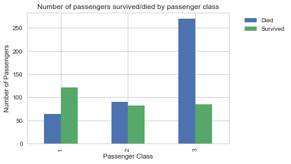

```python
%pylab inline

# Plot a bar chart with passenger class in the x-axis and the number of passengers in the y-axis. The passengers are grouped
# into survived and died.
ax = survival_by_class.plot.bar()
ax.set(title = 'Number of passengers survived/died by passenger class',
       xlabel='Passenger Class', ylabel = 'Number of Passengers')
ax.legend(title='', bbox_to_anchor=(1.05,1),loc=2)
```

We can see that the number of survivors is more in the first class and there are more deaths than survivlas as we move on to the second and third classes.

But, there are more travellers in the third class than the first and second classes, hence it is not appropriate to compare the whole numbers.

Let's visualize the same data in the form of a 100% stacked bar chart.

To do this, we first normalize the number of survivals and deaths for each class and then plot them as a stacked bar chart.

```python
# normalized count for the number of passengers survived and died in each class.
survival_by_class_norm = pd.crosstab(titanic_no_missing['Pclass'],titanic_no_missing['Survived'],normalize='index')
survival_by_class_norm
```

| Survived Pclass | Died | Survived |
| --- | --- | --- |
| 1 | 0.344086 | 0.655914 |
| 2 | 0.520231 | 0.479769 |
| 3 | 0.760563 | 0.239437 |

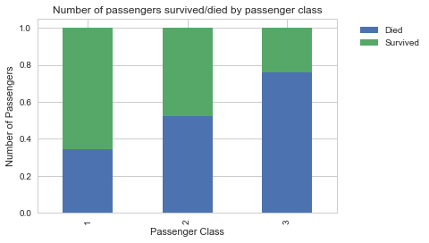

```python
%pylab inline
ax=survival_by_class_norm.plot.bar(stacked=True)
ax.set(title = 'Number of passengers survived/died by passenger class',
       xlabel='Passenger Class', ylabel = 'Number of Passengers')
ax.legend(title='', bbox_to_anchor=(1.05,1),loc=2)
```

Indeed the rate of survival decreases as we move from first class to third class.

**Test the hypothesis - There is a relationshio between passenger class and survival**

The 2 variables we are interested in studying are Pclass and Survived. Both Pclass and Survived are categorical variables. In order to determine if there is a significant association between these 2 variables, we will use a Chi-Square Test for Independence.

For the purposes of this test, we assume that the Titanic data is a random sample.

- Null hypothesis, Ho: Passenger class and Survival are independent
- Alternate hypothesis, Ha: Passenger class and Survival are not independent

For this analysis, the significant level is 0.05.

```python
# Use the chi square method from scipy.stats to calculate the chi square value,P-value, degrees of freedom and expected frequency
chi2,p,dof,expected = chi2_contingency(survival_by_class,correction=False)
print 'p-value: ', p
```

```
p-value:  6.70986174976e-21
```

P value 6.70986174976e-21 is lesser than the significance level 0.05. Hence we reject the null hypothesis. There is a relationship between Passenger class and Survival.

## 4.2 Were women more likely to survive than men?

To analyze this, let's first group the data by gender.

```python
# group by gender and survived and get the count of passengers
titanic_groupby_gender = titanic_no_missing.groupby(['Survived', 'Sex'],as_index=False)['PassengerId'].count()
titanic_groupby_gender
```

|  | Survived | Sex | PassengerId |
| --- | --- | --- | --- |
| 0 | Died | female | 64 |
| 1 | Died | male | 360 |
| 2 | Survived | female | 197 |
| 3 | Survived | male | 93 |

More women survived than men.

75% of the women onboard survived the disaster as opposed to only 21% of men who survived.

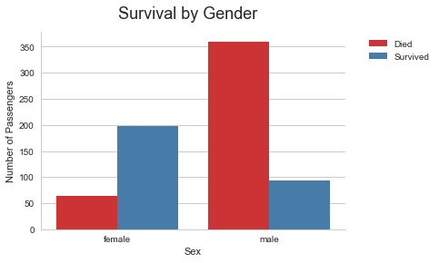

```python
#Plot a bar chart with survival counts for male and female passengers
ax=sns.barplot(x='Sex',y = 'PassengerId',hue='Survived', data = titanic_groupby_gender, palette='Set1')

#Remove the axis line on the rightside and the top
sns.despine()

#Add a title for the chart
sns.plt.suptitle('Survival by Gender',fontsize=18)

ax.set(ylabel='Number of Passengers')
ax.legend(title='', bbox_to_anchor=(1.05,1),loc=2)
```

To see the distribution of survival by gender across travel classes, let's plot survival count by passenger class and sex.

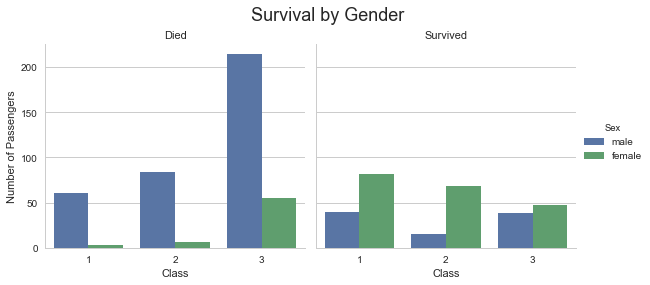

```python
# Plot a set of bars classifying number of passengers survived and died by class and sex.
g=sns.factorplot(x='Pclass',col ='Survived',data=titanic_no_missing,hue='Sex',kind='count')
# Use the column names died and survived as the titles for the charts
g.set_titles(col_template="{col_name}")
g.set_axis_labels('Class','Number of Passengers');
# Adjust the space on top to avoid title overlapping with the column titles
plt.subplots_adjust(top=0.85)
sns.plt.suptitle('Survival by Gender',fontsize=18)
```

Of the 85 female passengers in first class, 82 passengers survived, a survival rate of over 96%. Compared to this only 46% of women in third class survived. **The women in first class had over a 100% more chance at survival than the women in third class.**

## 4.3 Did people with family aboard the ship have a better chance of survival?

```python
#Create a new column called Family=SipSp+Parch. This gives the total count of family members onboard for any passenger.
titanic_no_missing.loc[:,('Family')] = titanic_no_missing.loc[:,('SibSp')]+titanic_no_missing.loc[:,('Parch')]
#Group by family and survived and get the count of passengers
titanic_group_family = titanic_no_missing.groupby(['Family','Survived'],as_index=False)['PassengerId'].count()
```

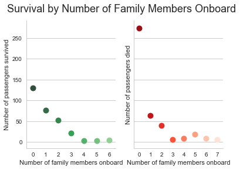

```python
# set up the matplotib figure to create 2 subplots that share a y axis
fig,ax = plt.subplots(1,2,sharey=True)
sns.set(style="white", color_codes=True)

# Draw two stripplots, one for the survived family group and one for non-survived family group
sns.stripplot(x='Family',y='PassengerId', size=10, palette = 'Greens_d',
              data=titanic_group_family[titanic_group_family['Survived']=='Survived'],ax=ax[0])
sns.stripplot(x='Family',y='PassengerId', size=10, palette = 'Reds_r',
              data=titanic_group_family[titanic_group_family['Survived']=='Died'],ax=ax[1])
#Remove the axis line on the right and top
sns.despine()
#Since Y value reads 'Survived' for the second chart too, correct the y-label
#Set individual x-labels for both the charts
ax[1].set(ylabel='Number of passengers died')
ax[0].set(ylabel = 'Number of passengers survived')
ax[0].set(xlabel = 'Number of family members onboard')
ax[1].set(xlabel = 'Number of family members onboard')
sns.plt.suptitle('Survival by Number of Family Members Onboard',fontsize=18)
```

**Calculating the Pearson's correlation coefficient for Family and Survival**

```python
# Create a copy of the titanic_no_missing in order to temporarily put the Survived values back to 0 and 1
# to calculate the Pearson's coefficient.
titanic_df_corr = titanic_no_missing.copy()
titanic_df_corr['Survived'].replace({'Survived':1,'Died':0},inplace=True)
titanic_df_corr['Family'].corr(titanic_df_corr['Survived'])
```

```
0.042787049552755897
```

As seen from the graph , the presence of more family members on board did not result in more survival. Pearson's coefficient for correlation between family and survival is 0.04. This value does not indicate a strong correlation.

Hence we can conclude that there does not seem to be a correlation between having family members on board and the rate of survival.

## 4.4 Did age impact survival?

We already saw in 4.2 that women had a better chance of survival than men. Logic would suggest that women and children would have been rescued first. Let us see if this was the case.

We will use a violin plot to see the distribution of survival across ages for male and female passengers in each class.

A violin plot is similar to a box plot and is useful to see the distribution of data across one or more categorical variables such that they can be compared. Unlike a boxplot, a violin plot features the kernel density estimation instead of actual datapooint.

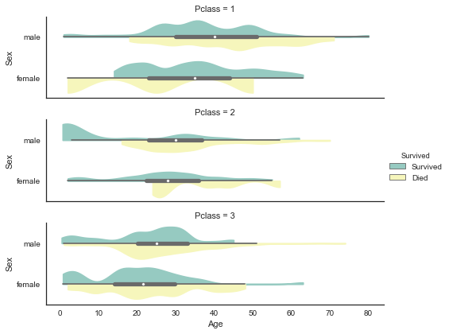

```python
# A violin plot with Age, Sex and Survived plotted horizontally with one Pclass on each row
f = sns.factorplot('Age','Sex',hue='Survived',palette='Set3',hue_order=['Survived','Died'],
                   row='Pclass', orient ='h',size=2,aspect =3.5,
                   data=titanic_no_missing, kind='violin',split=True, cut=0, bw=.2)
```

We can see that in classes 1 and 2, females and children seem to have been rescued first (with the exception of few in class 1). In class 3 this does not seem to be the case.

We do not see real trends for the impact of age on survival.

Hence we can conclude that age has an impact on survival, but the impact does not seem to be significant.

## 4.5 What is the combined role of class, sex and age on survival?

Now that we have analyzed these variables individually, let's explore all these variables together. Let's draw a grid with the survival counts for each class by age, differentiated by sex.

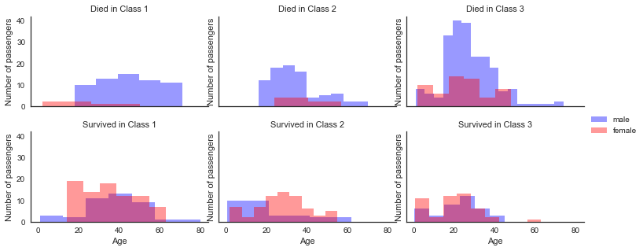

```python
#Create a color palette
pal_g = dict(male='blue', female='red')
#Create a facet grid with rows representing survived and coloumns representing class of travel. For each combination
#of these 2 variables, we will plot the number of survived passengers by age color separated for male and female.
g=sns.FacetGrid(titanic_no_missing, row='Survived', col='Pclass', hue='Sex',palette=pal_g, size=2.3,aspect=1.5)
g=(g.map(sns.distplot,'Age',kde=False).set_titles('{row_name} in Class {col_name}')).add_legend(title='')
g.set(ylabel='Number of passengers')
```

Some inferences from the above visual:

1. There were more male casulalities across most age groups.
2. More women survived the titanic disaster.
3. Most women in Class 1 and Class 2 survived.
4. Most men, women and children under the age of 20 in Class 1 and Class 2 survived.
5. No men above the age of 50 survived in Class 3.

# 5. Conclusion

4 variables were analyzed for impact on survival rate:

1. Travel Class
2. Sex
3. Family onboard
4. Age

In conclusion, let's look at one more visual, a heatmap that shows the correlation value for the above 5 variables.

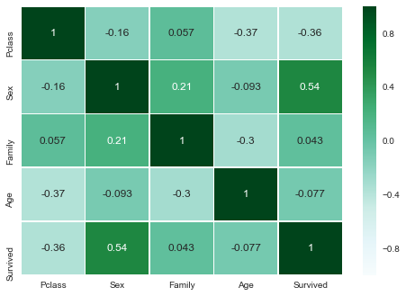

```python
# Create a subset with the fields of interest

titanic_subset = titanic_no_missing.filter(['Pclass','Sex','Family','Age','Survived'], axis=1)

#Convert sex to a numerical value, male=0,female=1 so that it can be included in the correlation heatmap
titanic_subset.loc[:,['Sex']]  = titanic_subset.loc[:,['Sex']].replace(['male','female'],[0,1])

#Convert Survived to a numerical value, died=0,survived=1 so that it can be included in the correlation heatmap
titanic_subset.loc[:,['Survived']]  = titanic_subset.loc[:,['Survived']].replace(['Died','Survived'],[0,1])

#Plot the heatmap
ax = sns.heatmap(titanic_subset.corr(),annot=True,linewidths=0.5,cmap='BuGn')
```

- Passengers in Class1 have a better chance of survival than Class2 and Class 2 passengers have a better chance of survival than Class3.
- Women are more likely to survive than men.
- Age has a minor impact on the survival rate.
- Travelling with family did not have a significant impact on survival.

# 6. References

- Data: https://d17h27t6h515a5.cloudfront.net/topher/2016/September/57e9a84c_titanic-data/titanic-data.csv
- https://www.kaggle.com/c/titanic
- https://en.wikipedia.org/wiki/RMS_Titanic
- https://chrisalbon.com/python/matplotlib_percentage_stacked_bar_plot.html
- http://stackoverflow.com/questions/13404468/t-test-in-pandas-python
- https://tryolabs.com/blog/2017/03/16/pandas-seaborn-a-guide-to-handle-visualize-data-elegantly/
- https://seaborn.pydata.org/
- http://seaborn.pydata.org/examples/distplot_options.html
- http://seaborn.pydata.org/generated/seaborn.violinplot.html
- http://matplotlib.org/api/figure_api.html#matplotlib.figure.Figure.subplots_adjust
- http://pandas.pydata.org/pandas-docs/stable/visualization.html
- http://www-users.cs.umn.edu/~ludford/stat_overview.htm